# Forecasting

Maurício Collaça

15 de agosto de 2018

## 0.1 Forecasting

- What forecasting methods are available that take account of trend, seasonality and other features of the data?
- How to measure the accuracy of your forecasts?
- How to choose a good forecasting model?

## 0.2 Creating time series objects in R

```r
library(readxl)
mydata <- read_excel("exercise1.xlsx")
```

```r
myts <- ts(mydata[c("Sales", "AdBudget", "GDP")], start = c(1981, 1), frequency = 4)
window(myts, end=c(1982,2))
```

```
         Sales AdBudget   GDP
1981 Q1 1020.2    659.2 251.8
1981 Q2  889.2    589.0 290.9
1981 Q3  795.0    512.5 290.8
1981 Q4 1003.9    614.1 292.4
1982 Q1 1057.7    647.2 279.1
1982 Q2  944.4    602.0 254.0
```

# 1 Time series Plots

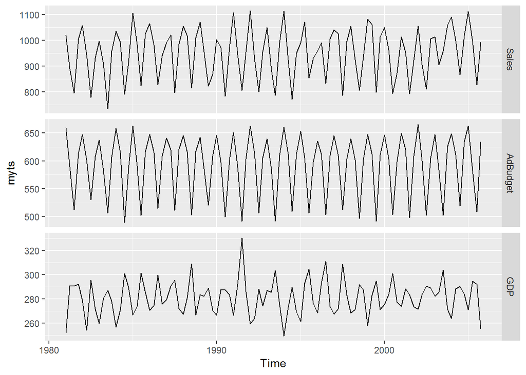

```r
library(forecast)
autoplot(myts, facets=TRUE)
```

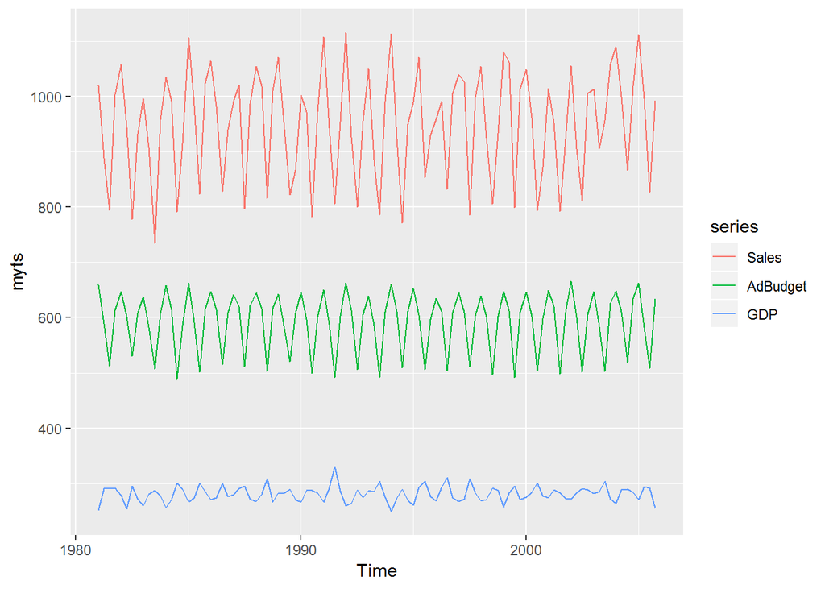

```r
autoplot(myts, facets=FALSE)
```

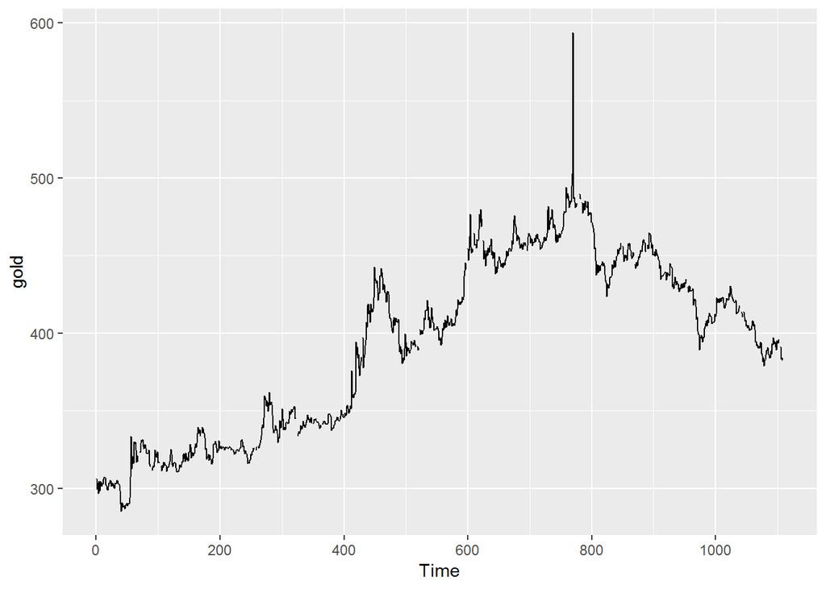

```r
autoplot(gold)
```

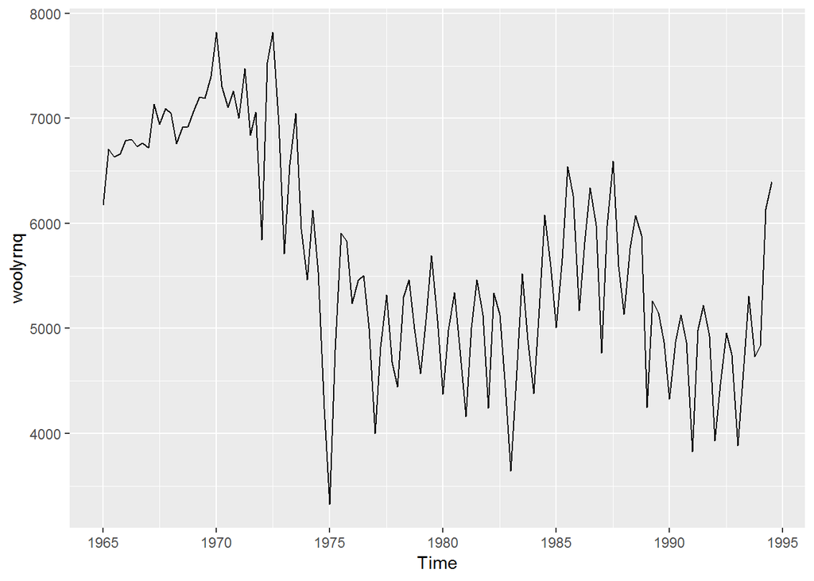

```r
autoplot(woolyrnq)
```

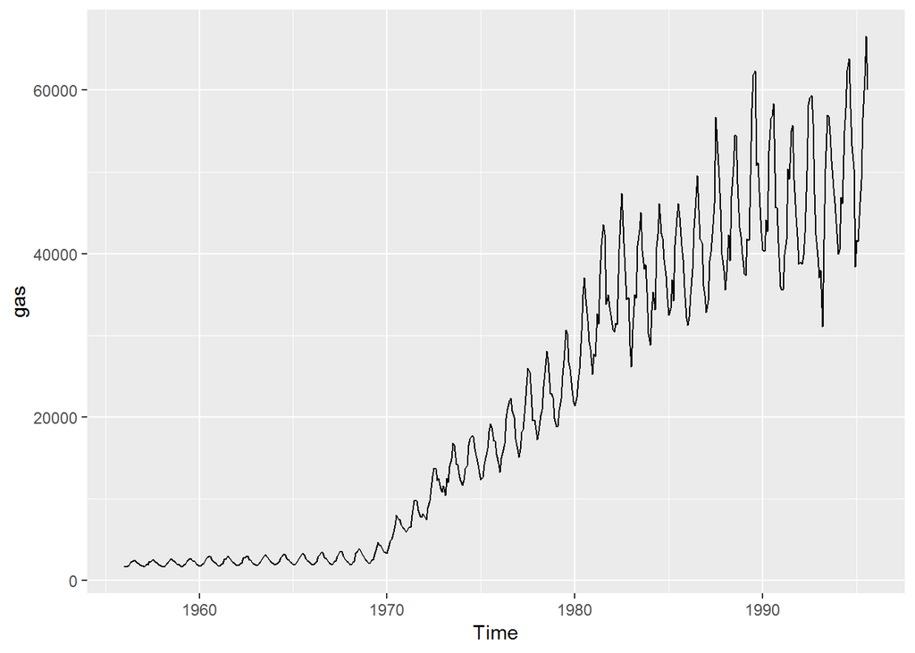

```r
autoplot(gas)
```

```r
frequency(gold)
```

```
[1] 1
```

```r
frequency(woolyrnq)
```

```
[1] 4
```

```r
frequency(gas)
```

```
[1] 12
```

# 2 Seasonal plots

```r
library(fpp2)
frequency(a10)
```

```
[1] 12
```

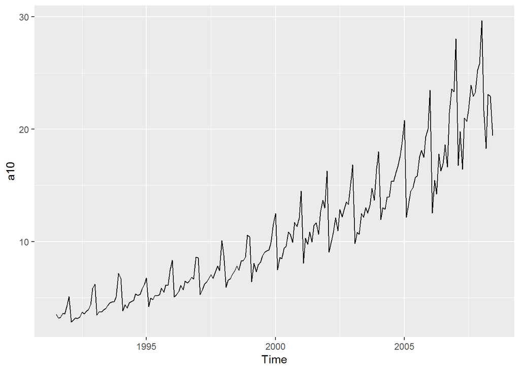

```r
autoplot(a10)
```

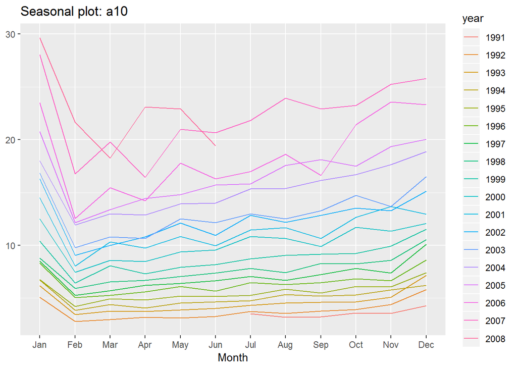

```r
ggseasonplot(a10)
```

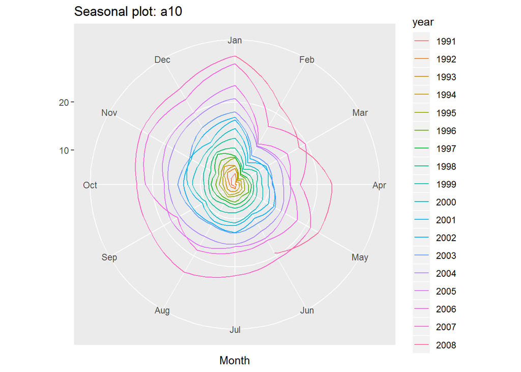

```r
ggseasonplot(a10, polar = TRUE)
```

```r
beer <- window(ausbeer, start=c(1992,1))
frequency(beer)
```

```
[1] 4
```

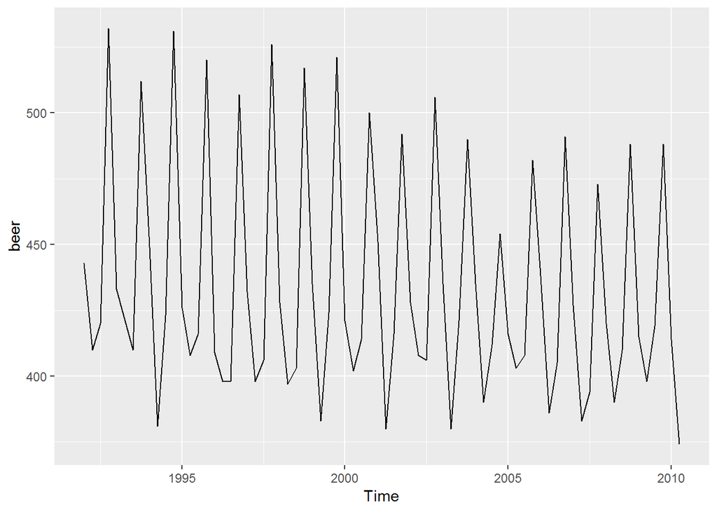

```r
autoplot(beer)
```

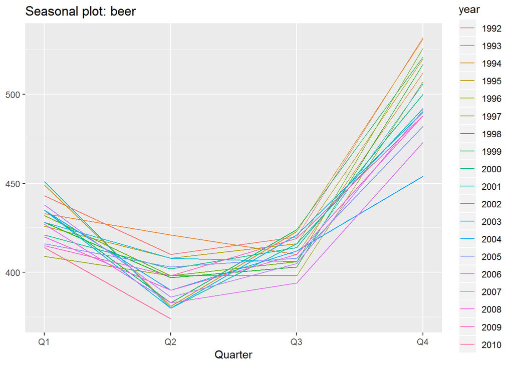

```r
ggseasonplot(beer)
```

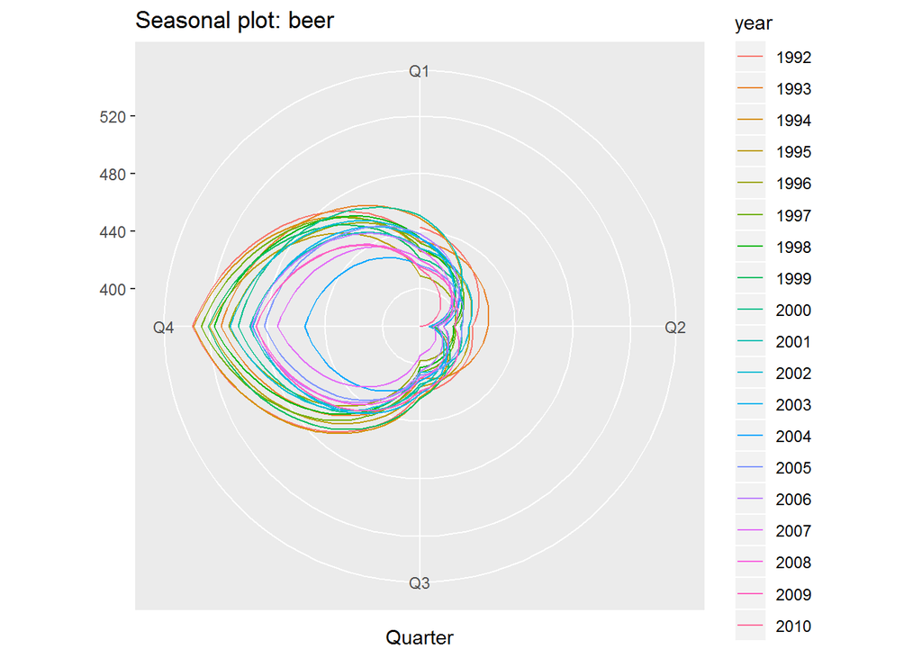

```r
ggseasonplot(beer, polar=TRUE)
```

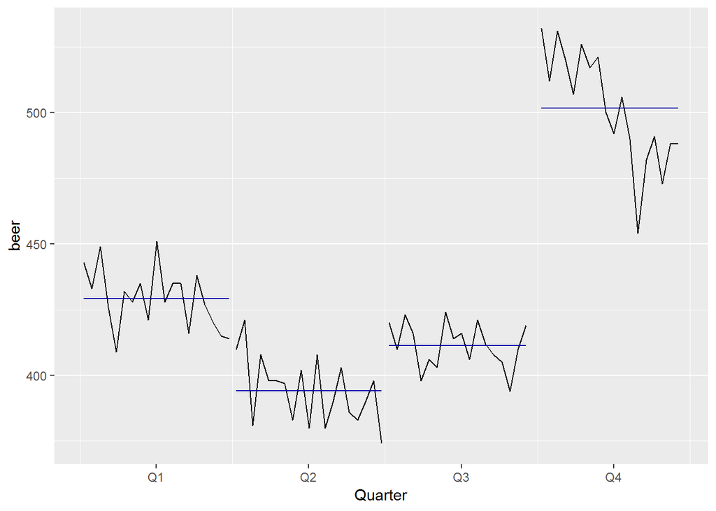

```r
ggsubseriesplot(beer)
```

# 3 Time series patterns

| Pattern | Description |
| --- | --- |
| Trend | A pattern exists involving a long-term increase OR decrease in the data (this is deliberaly a little vague because a trend is not a well-defined mathematical term) |
| Seasonal | A periodic pa!ern exists due to the calendar (e.g. the quarter, month, or day of the week) |
| Cyclic | A pattern exists where the data exhibits rises and falls that are not of fixed period (duration usually of at least 2 years) |

## 3.1 Examples of time series patterns

Trended and seasonal

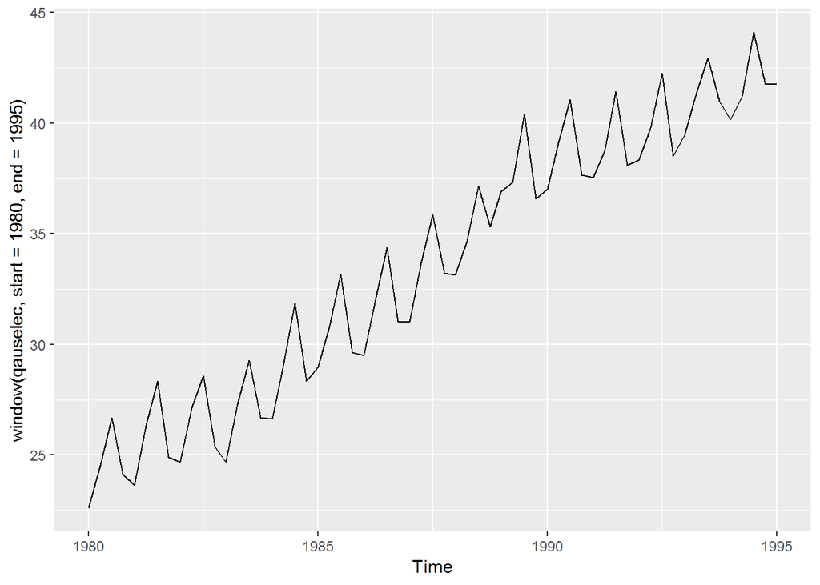

```r
autoplot(window(qauselec, start=1980, end=1995))
```

Trended, Seasonal and Cyclic

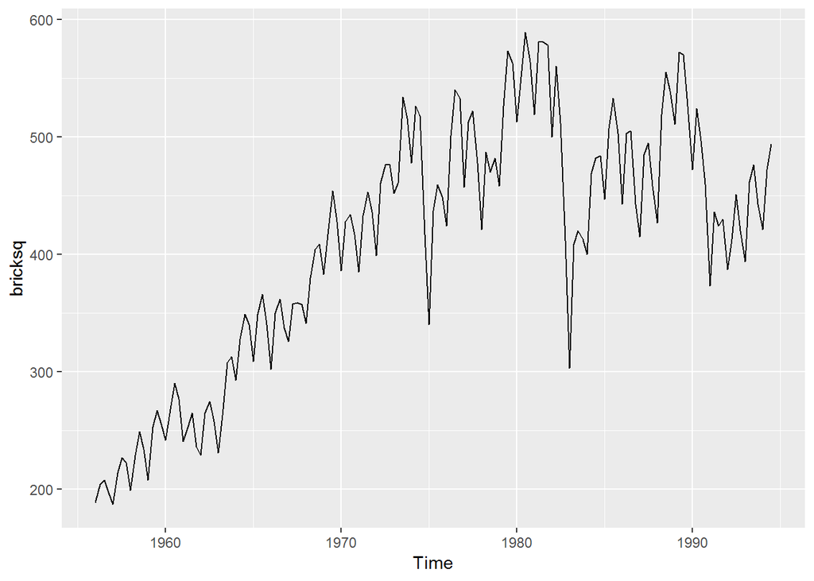

```r
autoplot(bricksq)
```

No seasonality, looks like a downward trend but it’s actually a part of a much longer cycle ( part of a cycle can look like a trend)

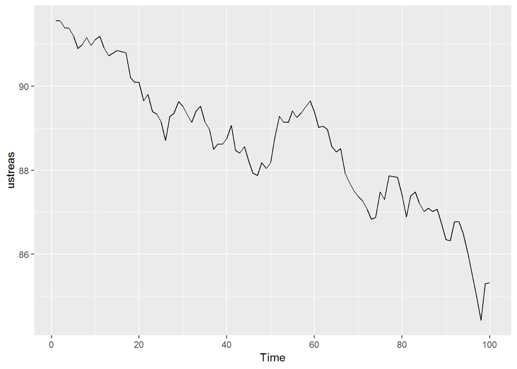

```r
autoplot(ustreas)
```

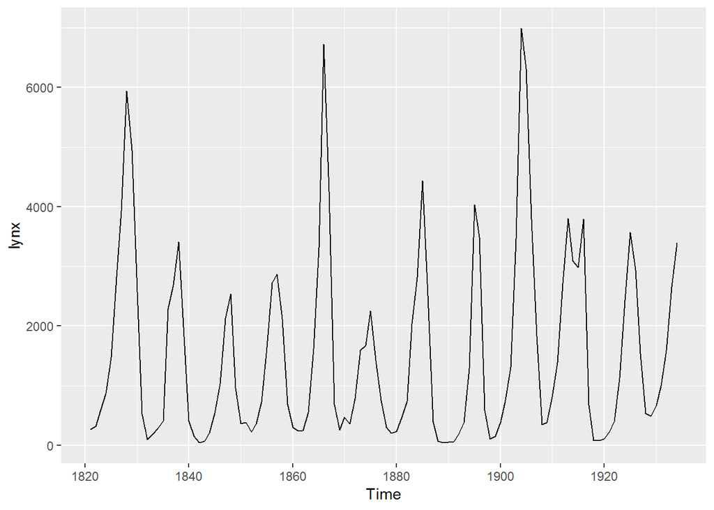

```r
autoplot(lynx)
```

# 4 Seasonal or cyclic?

Differences between seasonal and cyclic patterns:

- Seasonal pattern constant length vs. cyclic pattern variable length
- If both exists together, the average length of cycle pattern is longer than length of seasonal pa!ern
- The Magnitude (size) of the cycles tend to be more variable than the magnitude (size) of seasonal pattern

The timing of peaks and troughs is predictable with seasonal data, but unpredictable in the long term with cyclic data.

# 5 Autocorrelation of non-seasonal time series

autoplot of the oil data

```r
str(oil)
```

```
 Time-Series [1:49] from 1965 to 2013: 111 131 141 154 163 ...
```

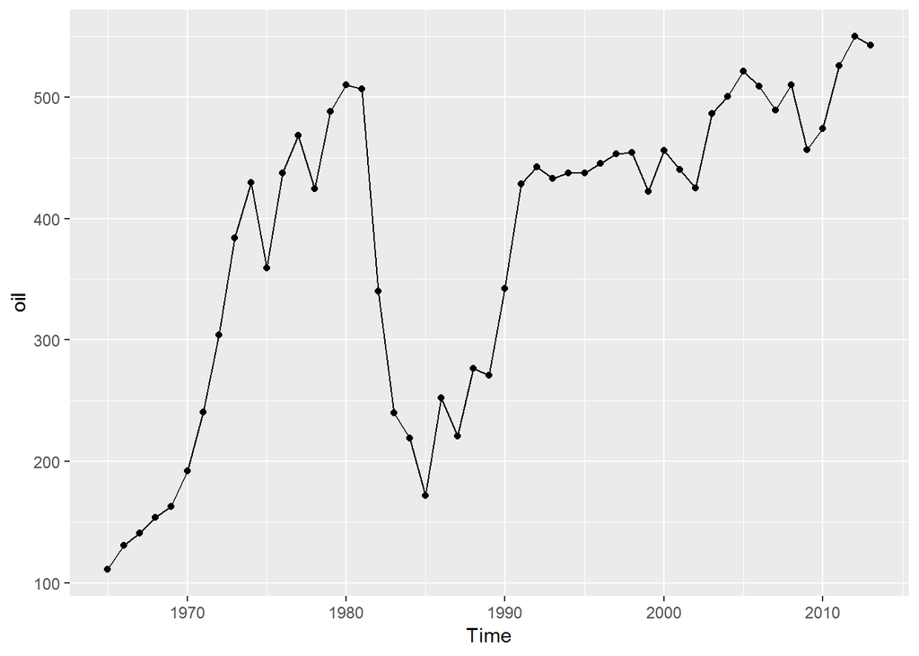

```r
autoplot(oil) + geom_point()
```

Create a lag plot of the oil data

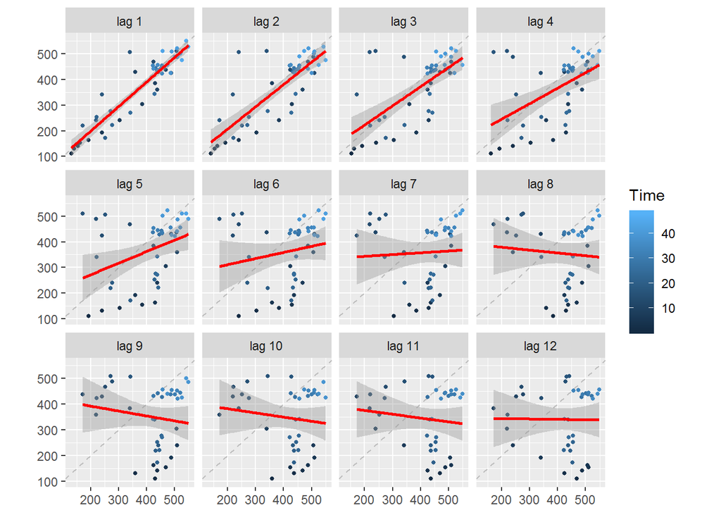

```r
gglagplot(oil, lags=12, do.lines = F) + geom_smooth(method=lm, color="red")
```

Create an ACF plot of the oil data

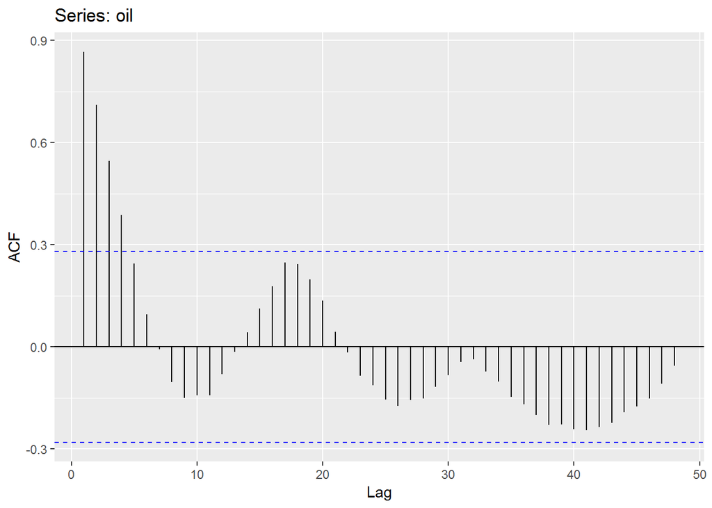

```r
ggAcf(oil, lag.max = Inf)
```

# 6 Autocorrelation of seasonal and cyclic time series

autoplot the annual sunspot numbers

```r
str(sunspot.year)
```

```
 Time-Series [1:289] from 1700 to 1988: 5 11 16 23 36 58 29 20 10 8 ...
```

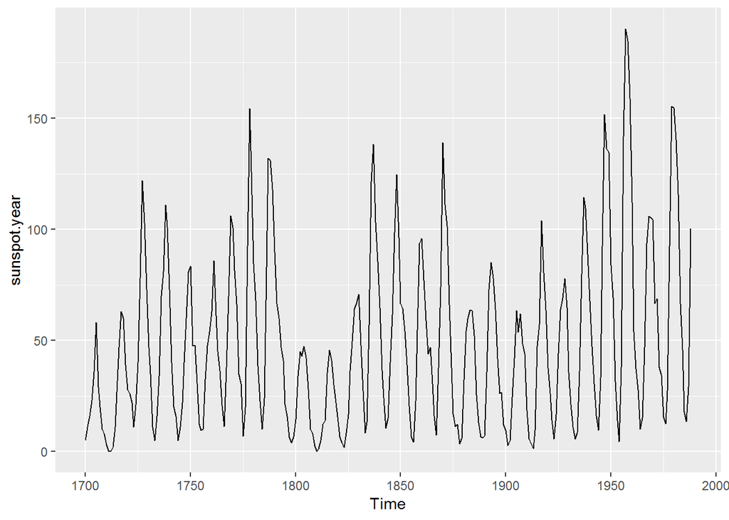

```r
autoplot(sunspot.year)# + geom_point()
```

Create a lag plot of the annual sunspot numbers

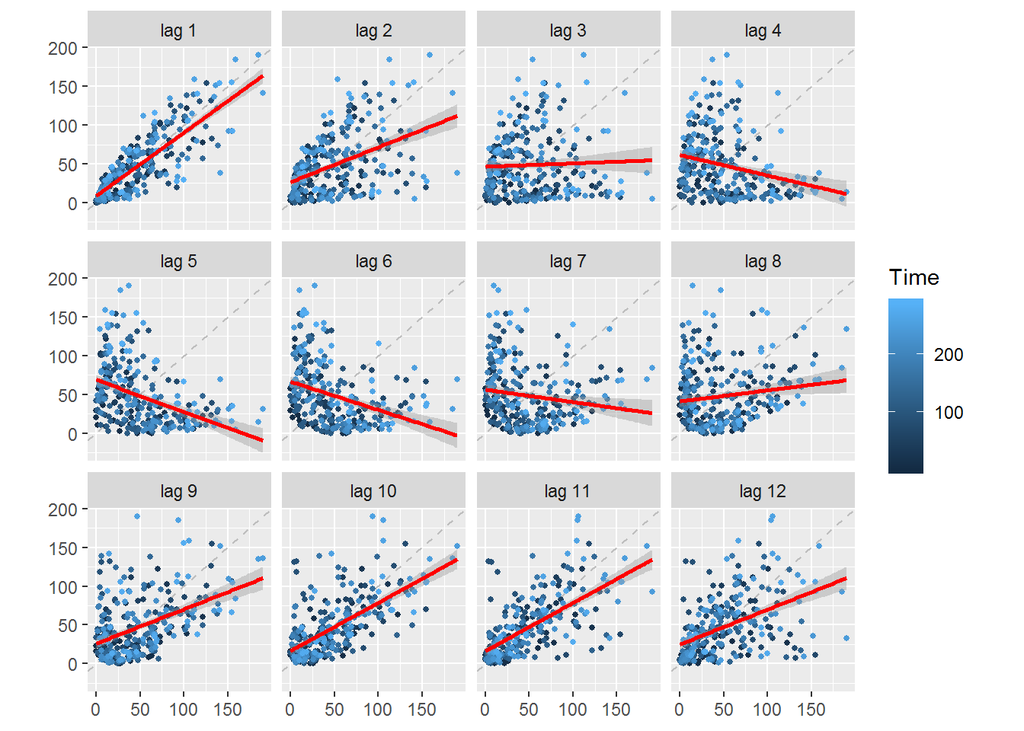

```r
gglagplot(sunspot.year, lags=12, do.lines = F) + geom_smooth(method=lm, color="red")
```

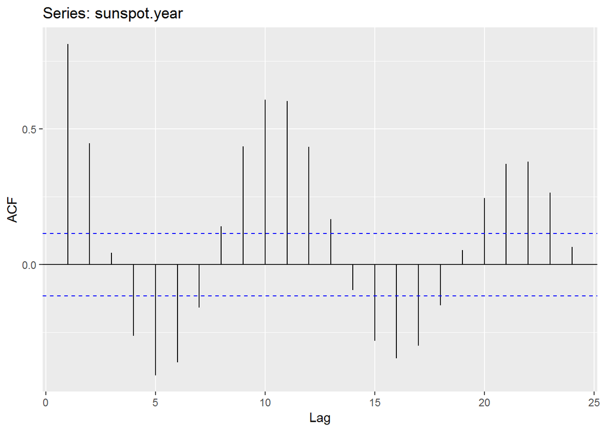

```r
ggAcf(sunspot.year)
```

Save the lag corresponding to maximum autocorrelation

```r
frequency(sunspot.year)
```

```
[1] 1
```

```r
(maxlag_sunspot <- 1)
```

```
[1] 1
```

autoplot the traffic on the Hyndsight blog

```r
str(hyndsight)
```

```
 Time-Series [1:365] from 1.43 to 53.4: 1157 1118 1310 874 890 1437 1263 1187 1506 1448 ...
```

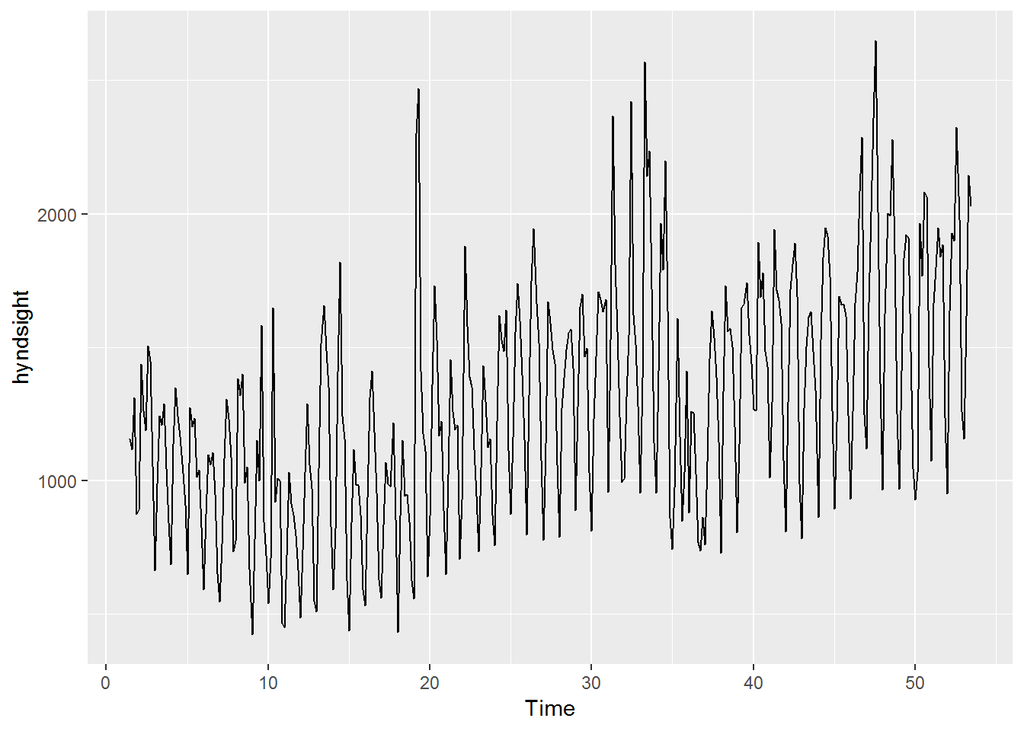

```r
autoplot(hyndsight)# + geom_point()
```

Create a lag plot of the traffic on the Hyndsight blog

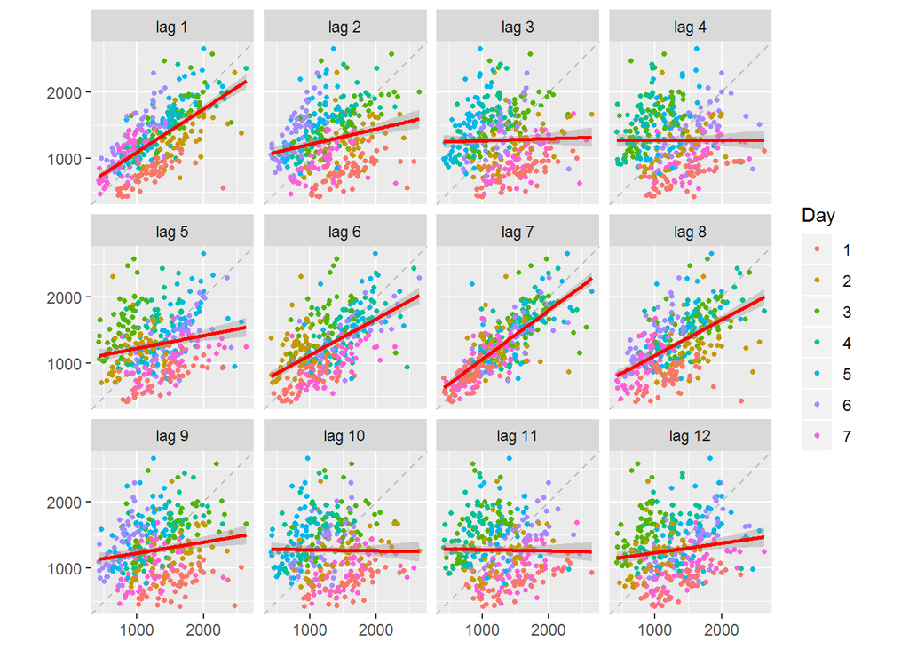

```r
gglagplot(hyndsight, lags=12, do.lines = F) + geom_smooth(method=lm, color="red")
```

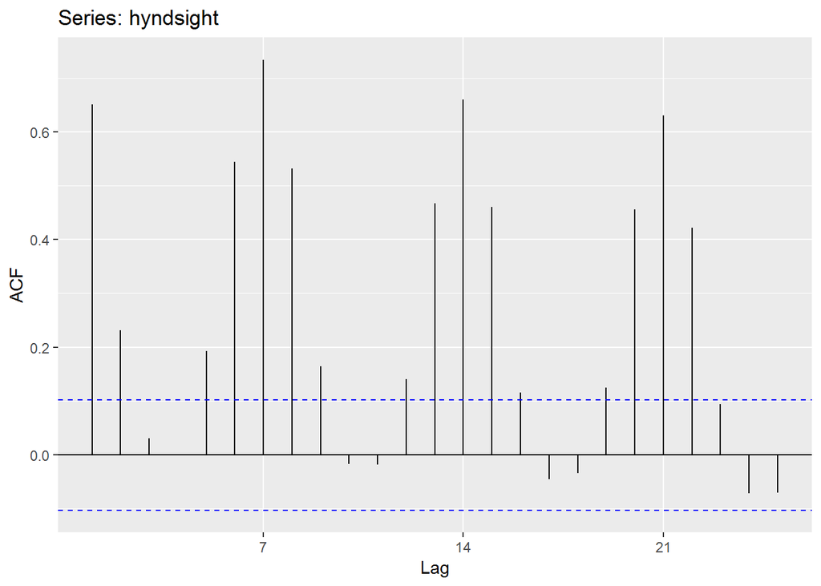

```r
ggAcf(hyndsight)
```

Save the lag corresponding to maximum autocorrelation

```r
frequency(hyndsight)
```

```
[1] 7
```

```r
(maxlag_hyndsight <- 7)
```

```
[1] 7
```

# 7 Hints

- Trends induce positive correlations in the early lags.
- Seasonality will induce peaks at the seasonal lags.
- Cyclicity induces peaks at the average cycle length.

# 8 White Noise

“White noise” is just a time series of iid data which can’t be used alone to build a forecasting model.

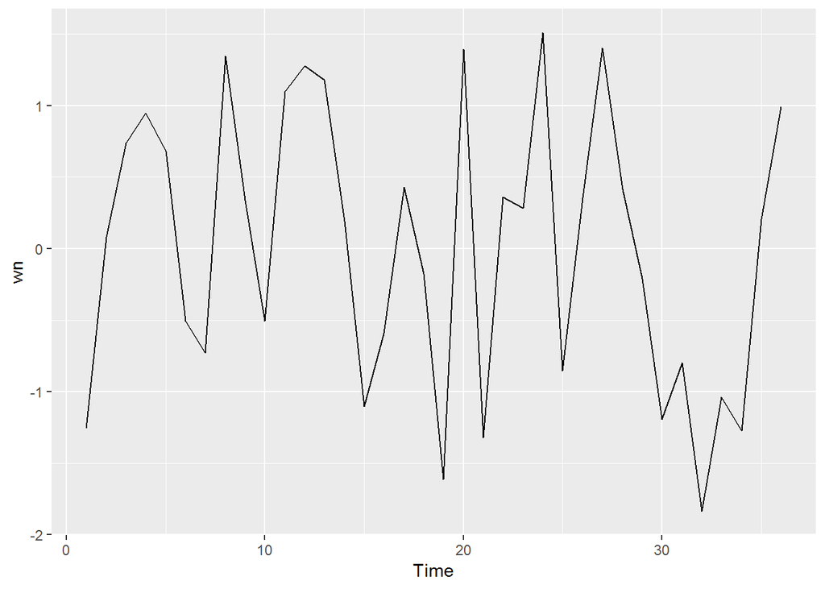

```r
wn <- ts(rnorm(36))
autoplot(wn)
```

- In WN it’s expected each correlation is close to zero
- 95% of all correlations for WN should lie between the blue lines, otherwise series is probably not WN.

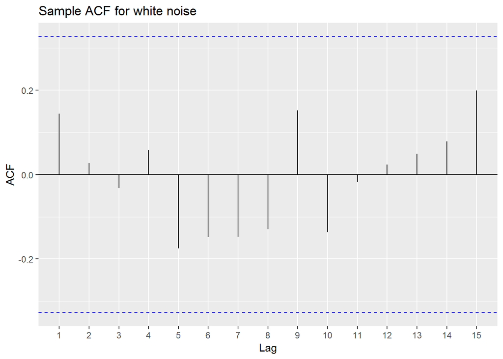

```r
ggAcf(wn) + ggtitle("Sample ACF for white noise")
```

# 9 Example: Pigs slaughtered

At first glance it looks relatively random or possibly a slightly upward trend, but it’s hard to see the difference from WN.

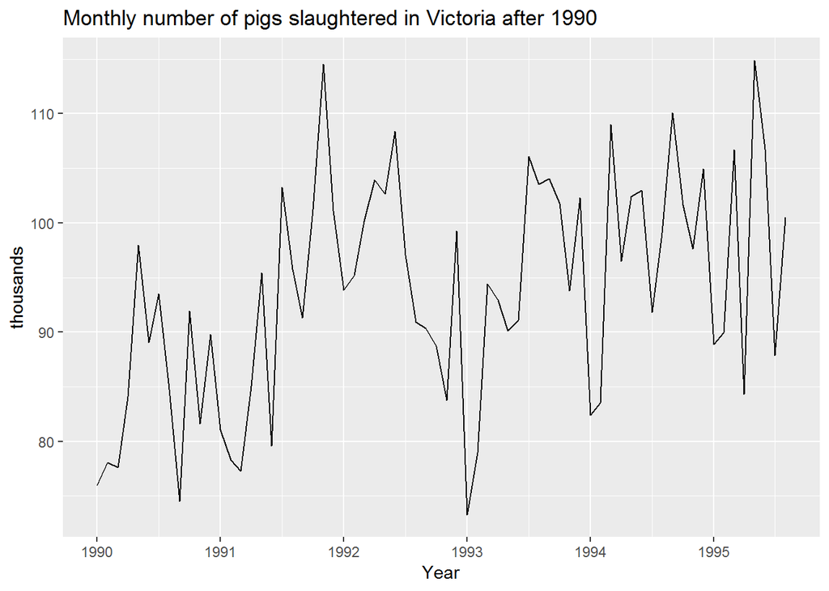

```r
pigs <- window(pigs, start=1990)
autoplot(pigs/1000) +
    xlab("Year") +
    ylab("thousands") +
    ggtitle("Monthly number of pigs slaughtered in Victoria after 1990")
```

ACF show the first 3 spikes are significantly larger than zero confirming it’s not WN. There is some information in data that can be used in building a forecasting model.

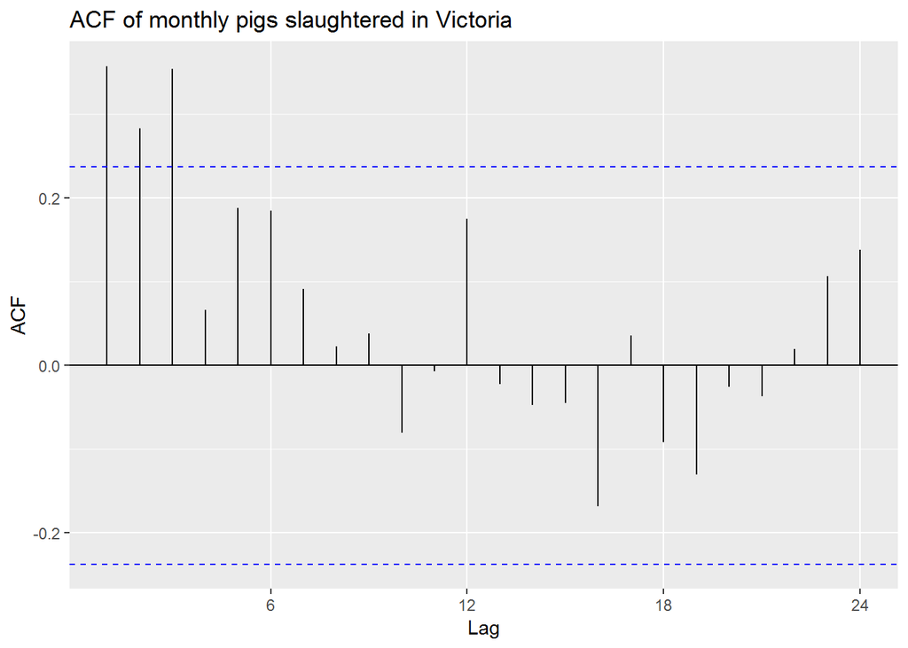

```r
ggAcf(pigs) + ggtitle("ACF of monthly pigs slaughtered in Victoria")
```

# 10 Ljung-Box test

Looking at the ACF is usefull but sometimes is easier to test all the autocorrelations together, rather then considering one separately.

The Ljung-Box test considers the first h autocorrelation values together.

A significant test (small p-value) indicates the data are probably not white noise.

Applying it to the first 24 autocorrelation in the pigs dataset.

```r
Box.test(pigs, lag = 24, fitdf = 0, type = "Ljung-Box")
```

```
    Box-Ljung test

data:  pigs
X-squared = 42.815, df = 24, p-value = 0.01044
```

The p-value is very small, thus rejecting the null hypothesis of an independent time series, than suggesting this is not WN.

# 11 White noise summary

- White noise is a time series that is purely random
- We can test for white noise by looking at an ACF plot or by doing a Ljung-Box test

# 12 Stock prices and white noise

As you learned in the video, white noise is a term that describes purely random data. You can conduct a Ljung-Box test using the function below to confirm the randomness of a series; a p-value greater than 0.05 suggests that the data are not significantly different from white noise.

There is a well-known result in economics called the **“Efficient Market Hypothesis”** that states that asset prices reflect all available information. A consequence of this is that the **daily changes in stock prices should behave like white noise (ignoring dividends, interest rates and transaction costs)**. The consequence for forecasters is that **the best forecast of the future price is the current price**.

You can test this hypothesis by looking at the closing stock price for Google ending on February 13, 2017.

## 12.1 Quandl data

```r
library(Quandl)
```

```r
Quandl.api_key(readLines("Quandl.api_key.txt",1))
goog <- Quandl("WIKI/GOOG", type="xts", start_date="1990-01-01")
goog <- goog["/2017-02-13"]
str(goog)
```

```
An 'xts' object on 2014-03-27/2017-02-13 containing:
  Data: num [1:727, 1:12] 568 561 567 559 565 ...
 - attr(*, "dimnames")=List of 2
  ..$ : NULL
  ..$ : chr [1:12] "Open" "High" "Low" "Close" ...
  Indexed by objects of class: [Date] TZ: UTC
  xts Attributes:
 NULL
```

```r
head(goog[, "Close"])
```

```
            Close
2014-03-27 558.46
2014-03-28 559.99
2014-03-31 556.97
2014-04-01 567.16
2014-04-02 567.00
2014-04-03 569.74
```

```r
tail(goog[, "Close"])
```

```
            Close
2017-02-06 801.34
2017-02-07 806.97
2017-02-08 808.38
2017-02-09 809.56
2017-02-10 813.67
2017-02-13 819.24
```

Plot the original series

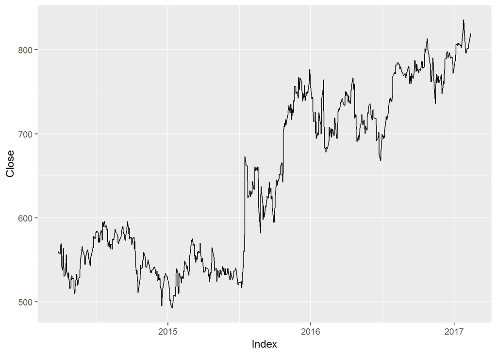

```r
autoplot(goog[, "Close"])
```

Plot the differenced series

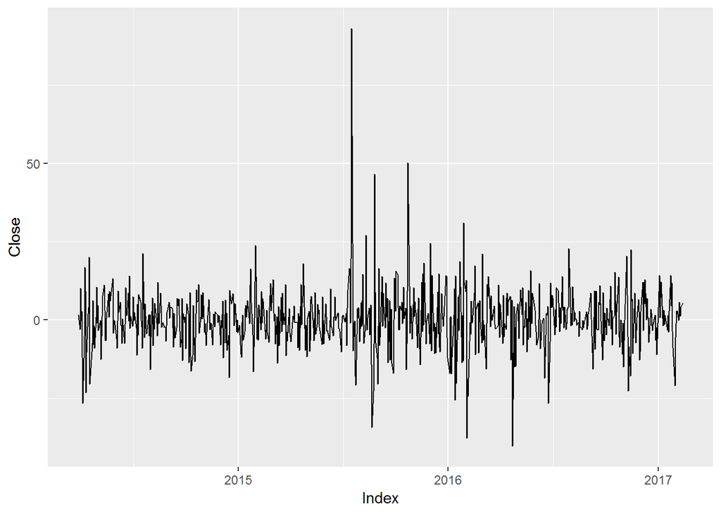

```r
autoplot(diff(goog[, "Close"]))
```

ACF of the differenced series

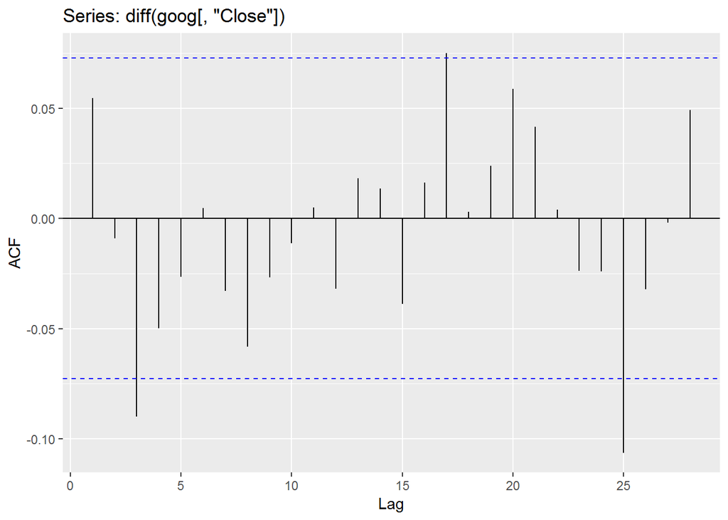

```r
ggAcf(diff(goog[, "Close"]))
```

Ljung-Box test of the differenced series

```r
Box.test(diff(goog[, "Close"]), lag = 10, type = "Ljung")
```

```
    Box-Ljung test

data:  diff(goog[, "Close"])
X-squared = 14.357, df = 10, p-value = 0.1573
```

The p-value higher than 0.05 resulted from the Ljung-Box test of differenced closing price until February 13, 2017 confirms the null hypothesis of White Noise.

## 12.2 quantmod data

```r
library(quantmod)
getSymbols("GOOG")
```

[output not shown]

[output not shown]

```
[1] "GOOG"
```

```r
str(GOOG)
```

```
An 'xts' object on 2007-01-03/2018-08-14 containing:
  Data: num [1:2925, 1:6] 231 233 240 242 241 ...
 - attr(*, "dimnames")=List of 2
  ..$ : NULL
  ..$ : chr [1:6] "GOOG.Open" "GOOG.High" "GOOG.Low" "GOOG.Close" ...
  Indexed by objects of class: [Date] TZ: UTC
  xts Attributes:
List of 2
 $ src    : chr "yahoo"
 $ updated: POSIXct[1:1], format: "2018-08-15 23:22:01"
```

```r
GOOG <- GOOG["/2017-02-13"]
head(GOOG[, "GOOG.Close"])
```

```
           GOOG.Close
2007-01-03   232.2842
2007-01-04   240.0686
2007-01-05   242.0209
2007-01-08   240.2276
2007-01-09   241.1814
2007-01-10   243.1486
```

```r
tail(GOOG[, "GOOG.Close"])
```

```
           GOOG.Close
2017-02-06     801.34
2017-02-07     806.97
2017-02-08     808.38
2017-02-09     809.56
2017-02-10     813.67
2017-02-13     819.24
```

Plot the original series

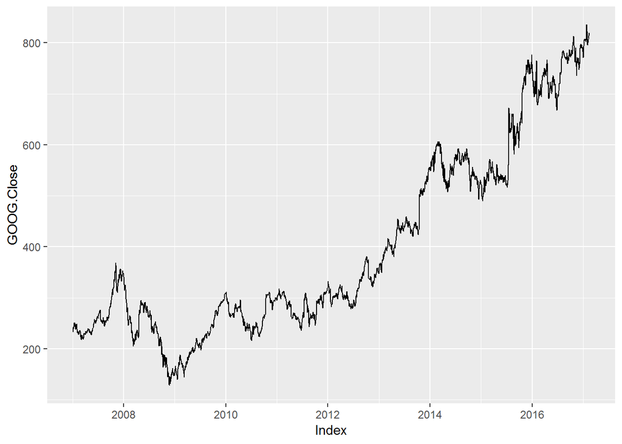

```r
autoplot(GOOG[, "GOOG.Close"])
```

Plot the differenced series

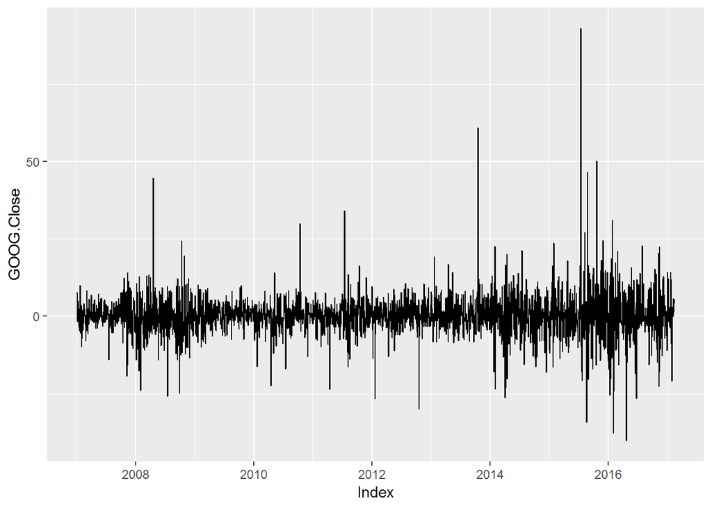

```r
autoplot(diff(GOOG[, "GOOG.Close"]))
```

ACF of the differenced series

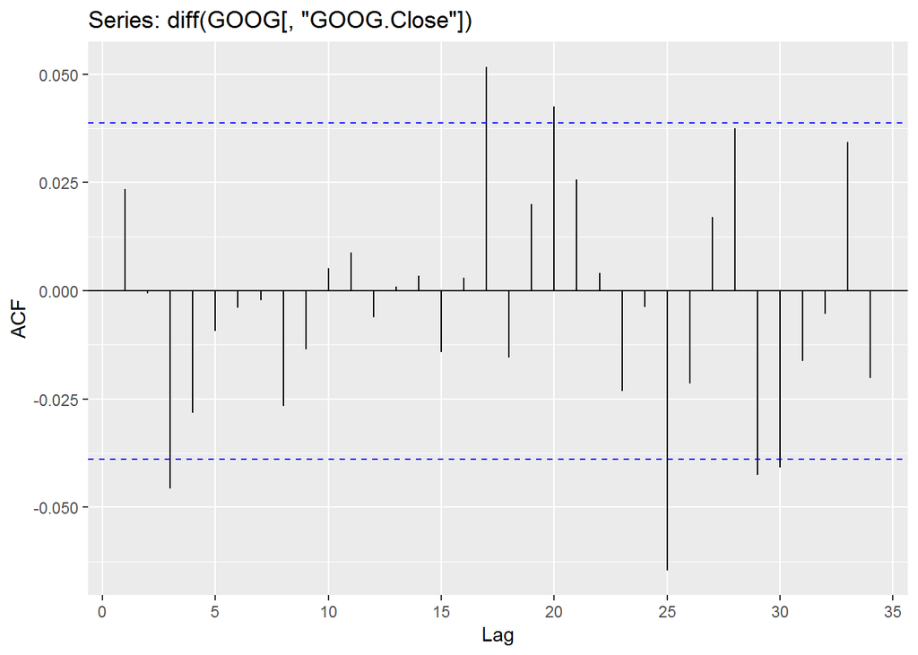

```r
ggAcf(diff(GOOG[, "GOOG.Close"]))
```

Ljung-Box test of the differenced series

```r
Box.test(diff(GOOG[, "GOOG.Close"]), lag = 10, type = "Ljung")
```

```
    Box-Ljung test

data:  diff(GOOG[, "GOOG.Close"])
X-squared = 11.377, df = 10, p-value = 0.3289
```

The p-value higher than 0.05 resulted from the Ljung-Box test of differenced closing price until February 13, 2017 confirms the null hypothesis of White Noise.